# Introduction to R functionality – Part 2

**Author:** Christina Dimitriadou (christina.delta.k@gmail.com)

**Date:** 10/04/2020

This is the second of 5 introductory notebooks to statistcs with R. In the first notebook I covered a few basic concepts on:

- Variables
- Vectors
- Sequences
- Functions
- R scripts

In this notebook you will learn how to handle data frames and matrices in R.

## Data frames

A data frame (also called tabular data) is data that is structured into raws and columns, each of which contains information about some thing. Data frames in R are extremely important and they are very frequently used. Generally, each raw in the data frame represents a unit of observation and each column to contain a different type of information about teh units of observation.

In R, tabular data is called **tidy data**

In this notebook we will be using a collection of modern packages known as **Tidyverse**. Tidyverse has its own slightly improved form of data frame, which is called *tibble*. Tidyverse is generally safer and makes data science look easier.

Note that this is a mere introduction to data frames. In the README.md file of this repo I also include a number of extra resources for further reading and exercising.

## Setting up

The first step is to ensure that you have the files that will be used in this tutorial and to install the *Tidyverse* packages.

First install the *Tidyverse* packages:

```r
# install tidyverse
install.packages("tidyverse")
```

Sometimes people have problems installing all the packages in Tidyverse (especially on windows machines). If that happens to you, you may be able to successfully install each package individually:

```r
install.packages(c("dplyr", "readr", "tidyr", "ggplot2"))
```

Now that we have loaded the data and installed our packages, the next step is to load the packages in order to be able to use them. Note that in R installing and loading packages are two different things:

- we install packages/libraries once and they are stored in our system
- we load the packages/libraries that we need in every R session, depending on what exactly we want to do on that session.

For now, we only need to use the tidyverse packages:

```r
library(tidyverse)
# if you installed each package individually then:
library(dplyr)
library(readr)
library(tidyr)
library(ggplot2)
```

The tidyverse package loads various other packages setting up an R environment ready to use. In this notebook we will be using built-in functions from the `dplyr`, `readr`, and `tidyr` packages, `ggpplot` is used to plot and visualise data.

R is a language with mini-languages within it that solve specific domain problems. For example, `dplyr` uses such a mini-language, a set of *verbs* (or functions) that work well together. `dplyr` in combination with `tidyr` use some more complex operations and provide a way to perform powerful manipulations on your data frames.

## Load the dataset

The file is in CSV format and it should be in the folder **intro_data**. I have a detailed description of the data set that we will use in the README.md file but, here is a short description: The dataset comes from a simple categorization task, where 24 participants (12 male, 12 female) were asked to classify stimuli briefly presented on the screen as living or non-living by a key-press. Stimuli consisted of 4 categories (scenes, objects, humans and animals), and every stimulus was presented 20 times across the entire experiment split in 8 blocks.

We will use the `read.csv` function to load (this comes with base R), however, `readr` has a function `read_csv` that could also be used. CSV stands for Comma Seperated Values and is a text format used to store tabular data.

```r
# change this to your own path (the path of where you have stored the data set)
# data = read.csv("~/Desktop/intro_toR/intro_data/rt_data/allcategoryrts.csv", header=FALSE, sep=";")
data = read.csv("~/Desktop/rt_data/allcategoryrts.csv", header=FALSE, sep=";")

data # to visualise
```

| V1 | V2 | V3 | V4 | V5 | V6 |
| --- | --- | --- | --- | --- | --- |
| 1 | 0.96055 | 2 | 1 | 1 | 1 |
| 1 | 0.94989 | 2 | 2 | 1 | 1 |
| 1 | 0.94882 | 2 | 3 | 1 | 2 |
| 1 | 1.19100 | 2 | 4 | 1 | 2 |
| 1 | 0.98093 | 1 | 5 | 1 | 3 |
| 1 | 0.98359 | 1 | 6 | 1 | 3 |
| 1 | 0.93582 | 1 | 7 | 1 | 4 |
| 1 | 0.92720 | 1 | 8 | 1 | 4 |
| 2 | 0.90046 | 2 | 1 | 1 | 1 |
| 2 | 0.91136 | 2 | 2 | 1 | 1 |

[output cut: 182 more lines]

```r
NA
```

Given that we do not have headers in our dataset the column names appear as V1, V2… (each column is a different variable and the rows are observations or units of those variables). The next step involves adding column names or headers:

```r
# add headers
colnames(data) = c("subj", "rt", "classes", "cat", "gender", "category")
```

Notice that we have two variables (column names) **cat** and **category**. Cat has 8 types (1:8) and cat has 4 types (1:4). This is because the stimuli belong to 4 major categories: scenes, objects, animals, humans, which can be subdivided into 4 more categories: indoor scenes & outdoor scenes, everyday small objects and vehicles, animal faces and whole bodies, human faces and whole bodies.

Note that we can also create a dataframe ourselves inside RStutio using the `tibble` funcion of the tidyverse package or the `data.frame` function in base R:

```r
# create a dataframe using the tibble function
tibble(num=c(1,2,3), letter=c("a","b","c"))
```

| num | letter |
| --- | --- |
| 1 | a |
| 2 | b |
| 3 | c |

The two arguments (num,letter) become the column names.

Note that there are many ways to load a dataset in RStudio besides using commands:

- on the bottom right panel choose the files browser and from your home directory go to the data path, click on the dataset and select *import dataset…*

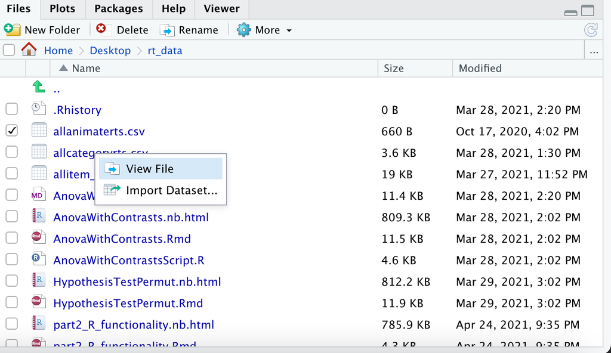

Imgur

Or on the top right panel press on *import Dataset*:

[figure not shown]

Imgur